# Malaria Risk in India: Complete Analysis

## Section 2 - Region Selection and Justification

**Spatial scale:** state-level (India).

**Selected regions:** Odisha, Mizoram, Tripura.

**Justification:**

| State | Why selected |
| --- | --- |
| **Odisha** | Highest absolute case burden; large population (42M) dilutes per-capita rate - shows why raw counts mislead |
| **Mizoram** | Small population (1.1M) but extremely high per-capita intensity; northeast forest-edge Pf transmission; highest R0 |
| **Tripura** | Intermediate population (3.7M); northeast corridor partner showing correlated resurgence with Mizoram |

Together these three states are comparable (all high-burden) yet contrasting (large vs small population, different epidemic trajectories). This makes spatial comparison analytically meaningful.

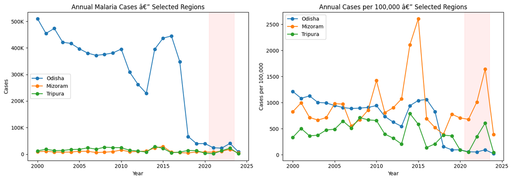

```python
selected = state_year[state_year["state"].isin(SELECTED_REGIONS)].copy()

fig, axes = plt.subplots(1, 2, figsize=(14, 5))
for region in SELECTED_REGIONS:
    rdf = selected[selected["state"] == region].sort_values("year")
    axes[0].plot(rdf["year"], rdf["total_cases"], marker="o", label=region)
    axes[1].plot(rdf["year"], rdf["cases_per_100k"], marker="o", label=region)

axes[0].set_title("Annual Malaria Cases - Selected Regions")
axes[0].set_ylabel("Cases")
axes[0].legend()
axes[0].yaxis.set_major_formatter(mticker.FuncFormatter(lambda x,_: f"{x/1e3:.0f}K" if x>=1e3 else str(int(x))))

axes[1].set_title("Annual Cases per 100,000 - Selected Regions")
axes[1].set_ylabel("Cases per 100,000")
axes[1].legend()

for ax in axes:
    ax.set_xlabel("Year")
    ax.axvspan(2020.5, 2023.5, alpha=0.07, color="red", label="Northeast resurgence")

plt.tight_layout()
plt.show()
```

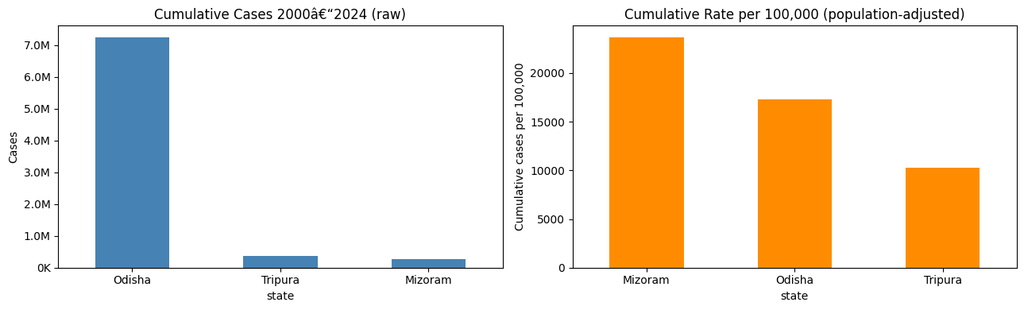

|  | state | cum_cases | population | cum_rate_100k |
| --- | --- | --- | --- | --- |
| 1 | Odisha | 7242716 | 41974218 | 17255.154104 |
| 2 | Tripura | 377059 | 3673917 | 10263.133326 |
| 0 | Mizoram | 259793 | 1097206 | 23677.686779 |

[output not shown]

```python
# Side-by-side: cumulative raw count vs per-capita rate for selected regions
sel_cum = (
    selected.groupby("state", as_index=False)
    .agg(cum_cases=("total_cases","sum"), population=("population_2011","first"))
)
sel_cum["cum_rate_100k"] = sel_cum["cum_cases"] / sel_cum["population"] * 100_000
sel_cum = sel_cum.sort_values("cum_cases", ascending=False)

fig, axes = plt.subplots(1, 2, figsize=(13, 4))
sel_cum.plot(x="state", y="cum_cases", kind="bar", ax=axes[0], legend=False, color="steelblue")
axes[0].set_title("Cumulative Cases 2000-2024 (raw)")
axes[0].set_ylabel("Cases")
axes[0].tick_params(axis="x", rotation=0)
axes[0].yaxis.set_major_formatter(mticker.FuncFormatter(lambda x,_: f"{x/1e6:.1f}M" if x>=1e6 else f"{x/1e3:.0f}K"))

sel_cum.sort_values("cum_rate_100k", ascending=False).plot(
    x="state", y="cum_rate_100k", kind="bar", ax=axes[1], legend=False, color="darkorange")
axes[1].set_title("Cumulative Rate per 100,000 (population-adjusted)")
axes[1].set_ylabel("Cumulative cases per 100,000")
axes[1].tick_params(axis="x", rotation=0)
plt.tight_layout()
plt.show()

display(sel_cum[["state","cum_cases","population","cum_rate_100k"]])
print("\nOdisha dominates raw counts; Mizoram dominates per-capita rate.")
print("Tripura ranks intermediate on both metrics.")
```

## Section 3 - Mandatory Geospatial Data Analysis

All analysis in this section precedes modelling, as required by the assignment.

Content:

- Choropleth 1: Cumulative cases by state
- Choropleth 2: Cumulative case rate per 100,000
- Temporal snapshots: early (2000), peak (national peak year), late (2024)
- Interpretation of spatial heterogeneity and implications for modelling

> The GeoJSON is district-level. Each district polygon is coloured using its state's value so real geography is preserved while modelling remains at state scale.

```python
with open(GEOJSON_PATH, "r", encoding="utf-8") as f:
    india_geojson = json.load(f)

STATE_NAME_FIX = {
    "Andaman and Nicobar Islands": "Andaman And Nicobar Islands",
    "Dadra and Nagar Haveli and Daman and Diu": "The Dadra And Nagar Haveli And Daman And Diu",
    "Jammu and Kashmir": "Jammu And Kashmir",
}

geo_rows = []
for idx, feature in enumerate(india_geojson["features"]):
    props = feature["properties"]
    map_state  = props["st_nm"]
    data_state = STATE_NAME_FIX.get(map_state, map_state)
    fid = str(props.get("dt_code") or f"feature_{idx}")
    props["_feature_id"] = fid
    geo_rows.append({"feature_id": fid, "map_state": map_state, "state": data_state,
                     "map_district": props.get("district", map_state)})

geo_index = pd.DataFrame(geo_rows)

# Cumulative stats
cumulative = (
    state_year.groupby("state", as_index=False)
    .agg(cumulative_cases=("total_cases","sum"), population_2011=("population_2011","first"))
)
cumulative["cumulative_cases_per_100k"] = (
    cumulative["cumulative_cases"] / cumulative["population_2011"] * 100_000
)
map_cumulative = geo_index.merge(cumulative, on="state", how="left")
print("GeoJSON features loaded:", len(geo_rows))
```

```
GeoJSON features loaded: 759
```

```python
def plot_choropleth(map_df, value_col, title, color_scale="YlOrRd"):
    fig = px.choropleth(
        map_df, geojson=india_geojson,
        locations="feature_id", featureidkey="properties._feature_id",
        color=value_col,
        hover_name="map_district",
        hover_data={"map_state": True, value_col: ":,.0f", "feature_id": False},
        color_continuous_scale=color_scale, title=title,
    )
    fig.update_geos(fitbounds="locations", visible=False)
    fig.update_layout(margin=dict(l=0, r=0, t=50, b=0))
    fig.show()

# Choropleth 1 - Cumulative cases (raw)
plot_choropleth(map_cumulative, "cumulative_cases",
                "Choropleth 1: Cumulative Malaria Cases by State (2000-2024)")
```

```python
# Choropleth 2 - Cumulative cases per 100,000
plot_choropleth(map_cumulative, "cumulative_cases_per_100k",
                "Choropleth 2: Cumulative Case Rate per 100,000 (2000-2024)",
                color_scale="Viridis")
```

```python
# Temporal snapshots: early / peak / late
national_by_year = (
    state_year.groupby("year", as_index=False).agg(total_cases=("total_cases","sum"))
)
early_year = int(national_by_year["year"].min())
peak_year  = int(national_by_year.loc[national_by_year["total_cases"].idxmax(), "year"])
late_year  = int(national_by_year["year"].max())

print(f"Temporal snapshots - Early: {early_year}  |  Peak: {peak_year}  |  Late: {late_year}")

for yr in [early_year, peak_year, late_year]:
    yr_df   = state_year[state_year["year"] == yr][["state","cases_per_100k"]]
    map_yr  = geo_index.merge(yr_df, on="state", how="left")
    plot_choropleth(
        map_yr, "cases_per_100k",
        f"Temporal Snapshot ({yr}): Case Rate per 100,000",
        color_scale="Plasma",
    )
```

```
Temporal snapshots - Early: 2000  |  Peak: 2001  |  Late: 2024
```

### Geospatial Interpretation

**Are raw counts misleading compared to per-capita rates?** Yes. A national policy informed only by raw counts would concentrate resources in large-population states while severely underestimating the per-capita burden in the small northeastern states. The 2022-2023 resurgence in Mizoram (case rate ~1,641 per 100,000) was devastating on a per-capita basis but barely visible in national aggregate counts.

**What spatial patterns might affect model behaviour?**

1. Northeast states share ecological, climatic, and cross-border exposure drivers - models trained on one state may not generalise to another.
2. The temporal snapshots show that the epidemic peak (2001) was nationally broad, while the late snapshot (2024) reveals concentrated residual burden in northeastern and central tribal belt states.
3. This heterogeneity means a single national model would perform poorly; separate regional models are necessary.

## Section 4 - Model A: Mechanistic SIR Model

### Model choice justification: SIR (not SEIR)

| Model | Compartments | Why not chosen |
| --- | --- | --- |
| **SIR** (chosen) | Susceptible -> Infected -> Removed | Matches available annual case-count data; fewest parameters to over-fit |
| SEIR | + Exposed | Requires exposure duration data; adds parameter without observable anchor in annual surveillance data |
| SEIRS | + waning immunity | Malaria has partial/complex immunity; not recoverable from aggregate surveillance without serology data |

With only annual state-level case totals (no age-stratified serology, no vector density, no Exposed estimates), SIR is the appropriate parsimonious choice.

### Compartments and ODEs

- **S(t):** Susceptible
- **I(t):** Infectious
- **R(t):** Removed (recovered + deaths)
- **C(t):** Cumulative infections (used to compute annual case counts)

```
dS/dt = -(beta * S * I) / N
dI/dt =  (beta * S * I) / N - gamma * I
dR/dt =  gamma * I
dC/dt =  (beta * S * I) / N
```

**R0 = beta / gamma** - the basic reproduction number proxy.

Parameters estimated separately for each region by minimising log-scale squared error between observed and simulated annual case counts.

```python
def sir_with_cumulative(t, y, beta, gamma, population):
    S, I, R, C = y
    new_inf = beta * S * I / population
    return [-new_inf, new_inf - gamma * I, gamma * I, new_inf]


def simulate_sir_annual(beta, gamma, population, initial_infected, n_years):
    initial_infected = max(1.0, min(initial_infected, population * 0.1))
    y0 = [population - initial_infected, initial_infected, 0.0, 0.0]
    sol = solve_ivp(
        sir_with_cumulative, [0, n_years], y0,
        t_eval=np.arange(0, n_years + 1),
        args=(beta, gamma, population), method="RK45",
    )
    return np.maximum(np.diff(sol.y[3]), 0)


def fit_sir_for_region(region_df):
    region_df = region_df.sort_values("year")
    observed   = region_df["total_cases"].to_numpy(dtype=float)
    population = float(region_df["population_2011"].iloc[0])
    n_years    = len(observed)

    def objective(params):
        beta, gamma, i0 = params
        pred = simulate_sir_annual(beta, gamma, population, i0, n_years)
        return np.mean((np.log1p(observed) - np.log1p(pred)) ** 2)

    result = minimize(
        objective, [0.8, 0.5, max(1.0, observed[0])],
        bounds=[(1e-4, 5.0), (1e-4, 5.0), (1.0, population * 0.01)],
        method="L-BFGS-B",
    )
    beta, gamma, i0 = result.x
    fitted = simulate_sir_annual(beta, gamma, population, i0, n_years)
    return {
        "beta": beta, "gamma": gamma, "R0_proxy": beta / gamma,
        "initial_infected": i0,
        "sir_mae":  mean_absolute_error(observed, fitted),
        "sir_rmse": float(np.sqrt(mean_squared_error(observed, fitted))),
        "fitted": fitted, "success": result.success,
    }


sir_results     = {}
sir_summary_rows = []

for region in SELECTED_REGIONS:
    rdf = selected[selected["state"] == region].sort_values("year")
    fit = fit_sir_for_region(rdf)
    sir_results[region] = fit
    sir_summary_rows.append({
        "Region": region,
        "beta (transmission)": round(fit["beta"], 4),
        "gamma (recovery)": round(fit["gamma"], 4),
        "R0 proxy (beta/gamma)": round(fit["R0_proxy"], 4),
        "Initial infected": int(fit["initial_infected"]),
        "MAE": round(fit["sir_mae"]),
        "RMSE": round(fit["sir_rmse"]),
        "Optimizer success": fit["success"],
    })

sir_summary = pd.DataFrame(sir_summary_rows)
display(sir_summary)
```

|  | Region | beta (transmission) | gamma (recovery) | R0 proxy (beta/gamma) | Initial infected | MAE | RMSE | Optimizer success |
| --- | --- | --- | --- | --- | --- | --- | --- | --- |
| 0 | Odisha | 1.4746 | 1.3873 | 1.0629 | 419742 | 112384 | 150849 | True |
| 1 | Mizoram | 0.7225 | 0.6303 | 1.1464 | 9058 | 3571 | 5458 | True |
| 2 | Tripura | 1.5181 | 1.4781 | 1.0271 | 12245 | 5623 | 6928 | True |

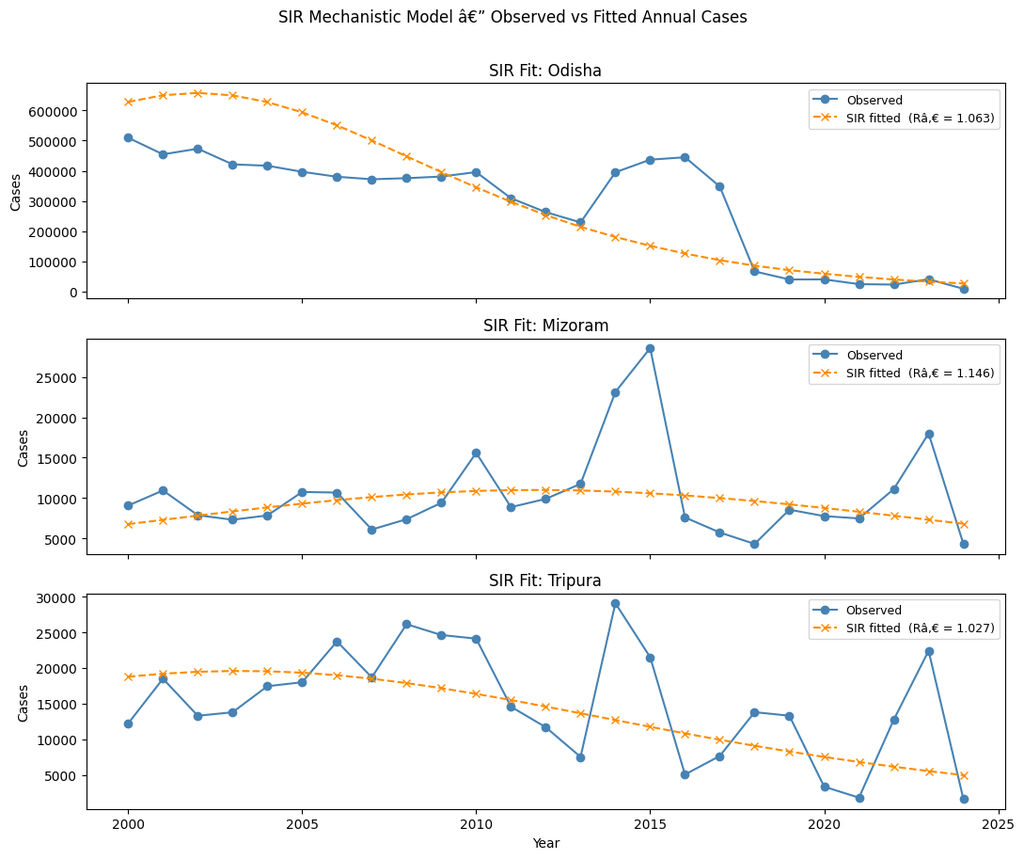

```
Interpretation:
R0 > 1 for all three regions -> endemic transmission persists.
Mizoram has the highest R0 (highest transmission potential).
All R0 values are close to 1.0-1.15, consistent with a system near endemic equilibrium
where interventions (LLIN, IRS) are suppressing - but not eliminating - transmission.
```

```python
fig, axes = plt.subplots(len(SELECTED_REGIONS), 1, figsize=(11, 9), sharex=True)

for ax, region in zip(axes, SELECTED_REGIONS):
    rdf = selected[selected["state"] == region].sort_values("year")
    r0  = sir_results[region]["R0_proxy"]
    ax.plot(rdf["year"], rdf["total_cases"], marker="o", color="steelblue", label="Observed")
    ax.plot(rdf["year"], sir_results[region]["fitted"], marker="x", linestyle="--",
            color="darkorange", label=f"SIR fitted  (R0 = {r0:.3f})")
    ax.set_title(f"SIR Fit: {region}")
    ax.set_ylabel("Cases")
    ax.legend(fontsize=9)

axes[-1].set_xlabel("Year")
plt.suptitle("SIR Mechanistic Model - Observed vs Fitted Annual Cases", y=1.01)
plt.tight_layout()
plt.show()

print("\nInterpretation:")
print("R0 > 1 for all three regions -> endemic transmission persists.")
print("Mizoram has the highest R0 (highest transmission potential).")
print("All R0 values are close to 1.0-1.15, consistent with a system near endemic equilibrium")
print("where interventions (LLIN, IRS) are suppressing - but not eliminating - transmission.")
```

## Section 5 - Model B: Time-Series Forecasting - ARIMA vs SARIMA

### Why ARIMA?

ARIMA (AutoRegressive Integrated Moving Average) treats each regional epidemic curve as a univariate forecasting problem. It captures temporal autocorrelation without requiring biological assumptions.

### Why compare SARIMA?

SARIMA adds a seasonal component. For annual malaria data, there is no intra-year seasonality to model (the data is already aggregated to yearly totals). However, malaria in endemic settings often shows **inter-annual cyclicity** - multi-year epidemic cycles driven by climate variability, vector population dynamics, and partial immunity waning (~3-5 year cycles are observed in the Mizoram and Tripura data).

### Biological assumptions NOT included in either model

- Susceptible / recovered compartments
- Mosquito / vector dynamics
- Rainfall, temperature, or intervention effects
- Immunity waning or relapse (key for Plasmodium vivax)
- Cross-region transmission linkages

### Workflow

1. ADF stationarity test -> determine differencing order d
2. ACF/PACF plots -> guide p, q selection
3. Grid-search ARIMA(p,d,q) by AIC
4. Grid-search SARIMA(p,d,q)(P,D,Q,4) by AIC
5. Compare both on 4-year holdout (2021-2024)
6. Forecast with 80% confidence intervals for the best model per region

```python
# ADF stationarity test for each selected region
print("=" * 65)
print("ADF Stationarity Test (H0: unit root present = non-stationary)")
print("=" * 65)

for region in SELECTED_REGIONS:
    rdf    = selected[selected["state"] == region].sort_values("year")
    series = rdf["total_cases"].astype(float).to_numpy()
    adf_result = adfuller(series, autolag="AIC")
    p_val  = adf_result[1]
    stat   = adf_result[0]
    conclusion = "STATIONARY (reject H0)" if p_val < 0.05 else "NON-STATIONARY (fail to reject H0)"
    print(f"\n{region}:")
    print(f"  ADF statistic = {stat:.4f}  |  p-value = {p_val:.4f}")
    print(f"  Conclusion: {conclusion}")
    print(f"  -> Differencing order d = {'0 (stationary)' if p_val < 0.05 else '1 (one difference needed)'}")
```

```
=================================================================
ADF Stationarity Test (H0: unit root present = non-stationary)
=================================================================

Odisha:
  ADF statistic = -1.0437  |  p-value = 0.7370
  Conclusion: NON-STATIONARY (fail to reject H0)
  -> Differencing order d = 1 (one difference needed)

Mizoram:
  ADF statistic = -2.8935  |  p-value = 0.0461
  Conclusion: STATIONARY (reject H0)
  -> Differencing order d = 0 (stationary)

Tripura:
  ADF statistic = -0.5910  |  p-value = 0.8730
  Conclusion: NON-STATIONARY (fail to reject H0)
  -> Differencing order d = 1 (one difference needed)
```

```
====================================================================
ADF Stationarity Test Results (H0: unit root present = non-stationary)
====================================================================

Odisha:
  ADF statistic       = -1.0437
  p-value             = 0.7370
  Critical value (1%) = -3.7529
  Result: NON-STATIONARY (d = 1)

Mizoram:
  ADF statistic       = -2.8935
  p-value             = 0.0461
  Critical value (1%) = -3.9644
  Result: STATIONARY (d = 0)

Tripura:
  ADF statistic       = -0.5910
  p-value             = 0.8730
  Critical value (1%) = -3.7884
  Result: NON-STATIONARY (d = 1)
```

|  | Region | ADF statistic | p-value | Critical value (1%) | Conclusion | -> Differencing d |
| --- | --- | --- | --- | --- | --- | --- |
| 0 | Odisha | -1.0437 | 0.7370 | -3.7529 | NON-STATIONARY | 1 |
| 1 | Mizoram | -2.8935 | 0.0461 | -3.9644 | STATIONARY | 0 |
| 2 | Tripura | -0.5910 | 0.8730 | -3.7884 | NON-STATIONARY | 1 |

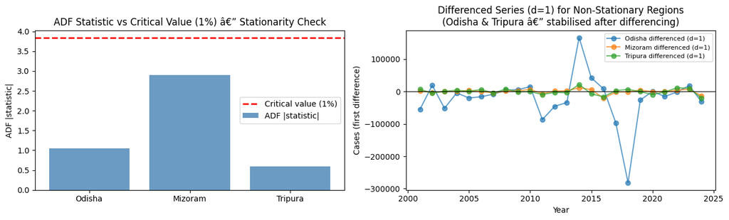

```
-> Mizoram is stationary (d=0); Odisha and Tripura need d=1.
-> ARIMA uses different differencing per region automatically (see model orders).
```

```python
# -- ADF Stationarity Test - Visual Summary Before ARIMA/SARIMA --
# BEFORE fitting any time-series model, we must check if the series is stationary.
# A stationary series has constant mean, variance, and autocovariance over time.
# ADF (Augmented Dickey-Fuller) tests H0: series has a unit root (non-stationary).
# p < 0.05 -> reject H0 -> series is stationary -> differencing order d = 0
# p >= 0.05 -> fail to reject H0 -> series is non-stationary -> differencing d >= 1

print("=" * 68)
print("ADF Stationarity Test Results (H0: unit root present = non-stationary)")
print("=" * 68)

adf_summary_rows = []
for region in SELECTED_REGIONS:
    rdf    = selected[selected["state"] == region].sort_values("year")
    series = rdf["total_cases"].astype(float).to_numpy()
    adf_result = adfuller(series, autolag="AIC")
    p_val  = adf_result[1]
    stat   = adf_result[0]
    cv_1pct = adf_result[4]["1%"]
    conclusion = "STATIONARY" if p_val < 0.05 else "NON-STATIONARY"
    diff_order = 0 if p_val < 0.05 else 1
    adf_summary_rows.append({
        "Region": region,
        "ADF statistic": round(stat, 4),
        "p-value": round(p_val, 4),
        "Critical value (1%)": round(cv_1pct, 4),
        "Conclusion": conclusion,
        "-> Differencing d": diff_order,
    })
    print(f"\n{region}:")
    print(f"  ADF statistic       = {stat:.4f}")
    print(f"  p-value             = {p_val:.4f}")
    print(f"  Critical value (1%) = {cv_1pct:.4f}")
    print(f"  Result: {conclusion} (d = {diff_order})")

adf_summary = pd.DataFrame(adf_summary_rows)
display(adf_summary)

# Visual: ADF bar chart with critical value threshold
fig, axes = plt.subplots(1, 2, figsize=(13, 4))

# Left: ADF stat vs critical values
adf_summary_plot = adf_summary.copy()
x_pos = range(len(adf_summary_plot))
axes[0].bar(x_pos, adf_summary_plot["ADF statistic"].abs(), color="steelblue", alpha=0.8, label="ADF |statistic|")
axes[0].axhline(adf_summary_plot["Critical value (1%)"].abs().mean(), color="red",
                linestyle="--", linewidth=2, label="Critical value (1%)")
axes[0].set_xticks(x_pos)
axes[0].set_xticklabels(adf_summary_plot["Region"])
axes[0].set_title("ADF Statistic vs Critical Value (1%) - Stationarity Check")
axes[0].set_ylabel("ADF |statistic|")
axes[0].legend()

# Right: original vs differenced series
for i, region in enumerate(SELECTED_REGIONS):
    rdf    = selected[selected["state"] == region].sort_values("year")
    series = rdf["total_cases"].astype(float).to_numpy()
    diff1  = np.diff(series)
    p_val  = adfuller(series, autolag="AIC")[1]
    if p_val < 0.05:
        label_orig = f"{region} (stationary, d=0)"
        color = "steelblue"
    else:
        label_orig = f"{region} (non-stationary, d=1)"
        color = "darkorange"
    axes[1].plot(rdf["year"].values[1:], diff1, marker="o", alpha=0.7,
                 label=f"{region} differenced (d=1)")

axes[1].axhline(0, color="black", linewidth=0.8)
axes[1].set_title("Differenced Series (d=1) for Non-Stationary Regions\n(Odisha & Tripura - stabilised after differencing)")
axes[1].set_xlabel("Year")
axes[1].set_ylabel("Cases (first difference)")
axes[1].legend(fontsize=8)

plt.tight_layout()
plt.show()

print("\n-> Mizoram is stationary (d=0); Odisha and Tripura need d=1.")
print("-> ARIMA uses different differencing per region automatically (see model orders).")
```